# Taxable Income and Tax Liabilities in 2008 (Bush Stimulus)

[Fan Wang](https://fanwangecon.github.io/)

2021-11-30

# 1 Taxable Income and Tax Liabilities in 2008

Taking advantage of [**snw_tax_liability**](https://github.com/FanWangEcon/PrjOptiSNW/blob/master/PrjOptiSNW/fgov/G:\repos\PrjOptiSNW\PrjOptiSNW\doc\fgov\snw_tax_liability.m) from the [**PrjOptiSNW Package**,](https://fanwangecon.github.io/PrjOptiSNW/) the function solves for tax liability.

We can study the effects of the 2008 Tax Rebate. The Tax rebate is a rebate based on how much tax was paid, so we need to know taxable income and tax liability. These differ by income, household marital status, and the count of children. Given an array of pre-tax income values, we compute for from 0 to 4 kids and both married and unmarried taxable-income and tax-liability at all points along the income array. Deductions are from 2008 income ([2008 IRS f1040](https://www.irs.gov/pub/irs-prior/f1040--2008.pdf)). Tax brackets from 2008 are here ([2008 IRS 1040tt](https://www.irs.gov/pub/irs-prior/i1040tt--2008.pdf)).

## 1.1 Taxable Income and Tax Liabilities in 2008 for 4 Income Levels

Call the function at four income levels. Solve for different kids count and by marital status.

```
bl_visualize = true;
ar_income = [20000, 30000, 50000, 70000];
snw_tax_liability(ar_income, true);
```

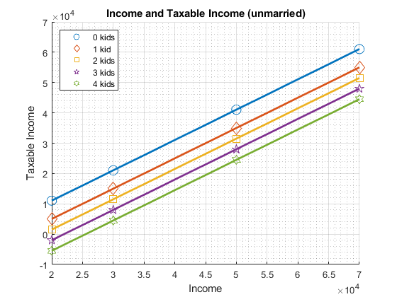

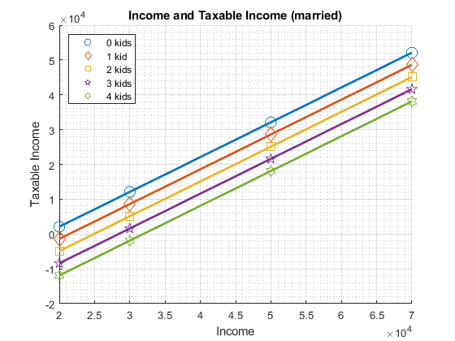

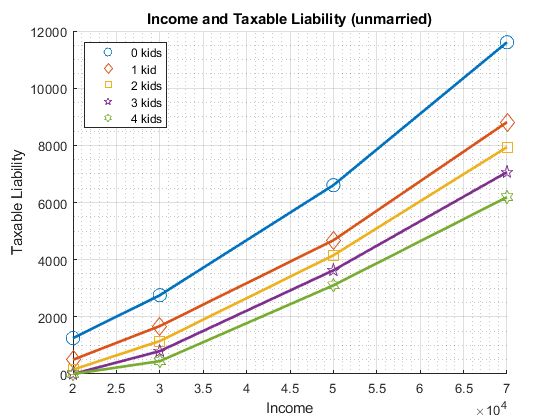

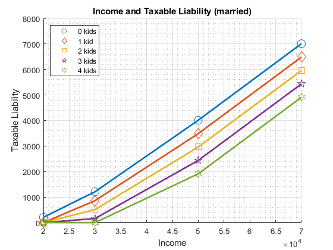

## 1.2 Taxable Income and Tax Liabilities in 2008 for 50 Income Levels

Call the function for incomes from 0 to 200k. Solve for different kids count and by marital status.

```
bl_visualize = true;
ar_income = linspace(0, 2e5, 50);
snw_tax_liability(ar_income, true);
```

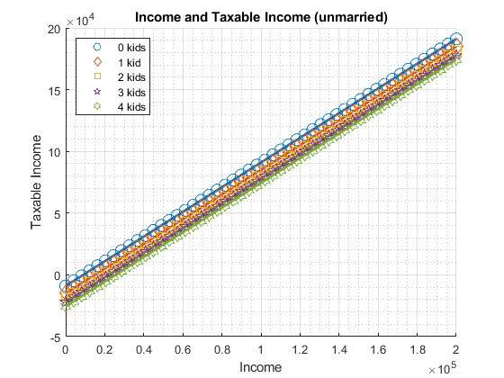

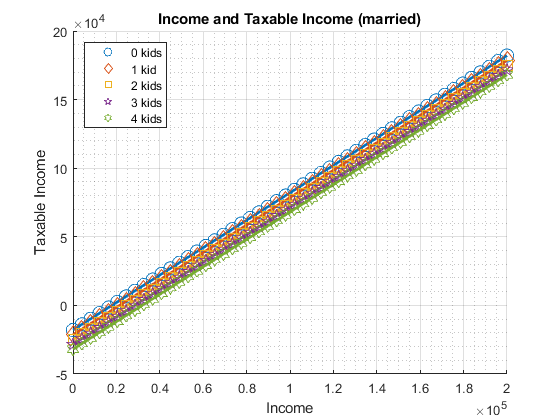

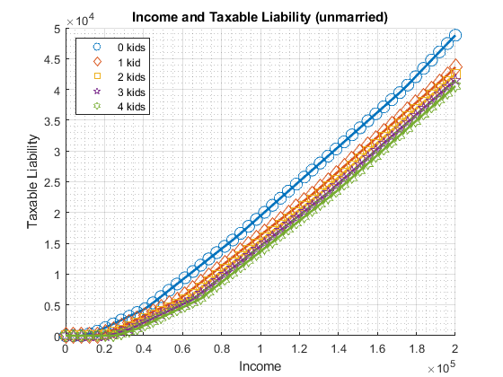

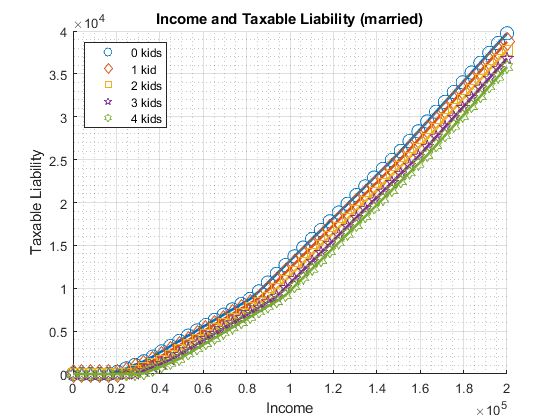